# Simple Linear Regression (Afifi Ch 6) Solutions

MATH 456 - Spring 2016

```r
library(knitr); library(rmarkdown);library(ggplot2);library(xtable)
options(xtable.comment = FALSE) # suppresses the % line from xtable
opts_chunk$set(warning=FALSE, message=FALSE)

fev <- read.delim("C:/GitHub/MATH456/data/Lung_020716.txt", sep="\t", header=TRUE)
names(fev) <- tolower(names(fev))
```

**1. Perform a regression analysis of weight on height for fathers**

**a. Determine the correlation coefficient and the regression equation.**

```r
cor(fev$fweight, fev$fheight)
```

```
## [1] 0.5211645
```

The correlation coefficient between weight and height for fathers is 0.52, this is a moderately strong correlation.

**b. Interpret the coefficients in context of the problem.**

```r
dad <- lm(fweight ~ fheight, data=fev)
coef(dad)
```

```
## (Intercept)     fheight
## -129.026658    4.491963
```

The regression equation is: $weight ~ -129.0 + 4.49height$ The intercept $\beta_{0} = -129.0$, is interpreted as the weight of a father who is 0cm tall. This is an impossible and nonsensical measurement. The slope coefficient $\beta_{1}$ is interpreted as the rate of change in weight as a a function of height. For every 1 cm taller a father is, his weight increases by 4.5lbs.

**2. Test that the coeffcients are significantly different from zero.**

```r
md <- xtable(summary(dad))
print(md, type='html')
```

|  | Estimate | Std. Error | t value | Pr(>\|t\|) |
| --- | --- | --- | --- | --- |
| (Intercept) | -129.0267 | 41.9123 | -3.08 | 0.0025 |
| fheight | 4.4920 | 0.6047 | 7.43 | 0.0000 |

The summary output for the linear model run in R automatically conducts a test for each individual coefficient in the regression model is significantly different from zero.

$H_{0}: \beta_{0} = 0$ vs $H_{A}: \beta_{0} \neq 0$. The test statistic for this test is -3.08, with a corresponding p-value of 0.0025. This indicates that the intercept is statistically significantly different from zero. Due to the interpretation of the data, this is not a meaningful test.

$H_{0}: \beta_{1} = 0$ vs $H_{A}: \beta_{1} \neq 0$. The test statistic for this test is 7.43, with a corresponding p-value <.0001. There is strong evidence to believe that the height of a father increases the weight of a father.

**3. Assess model fit graphically. Comment on any outliers.**

Check linearity:

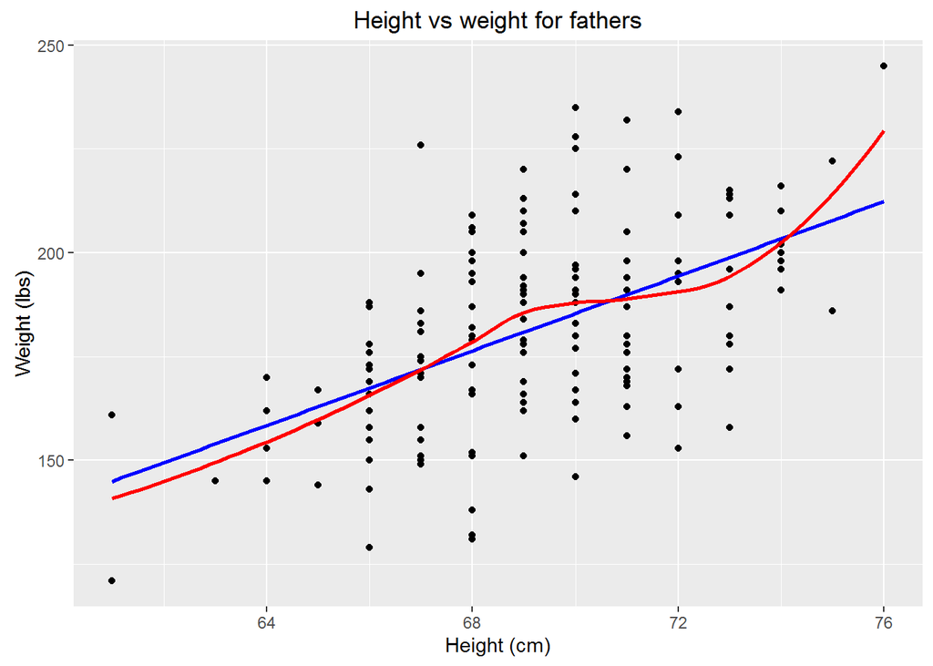

```r
qplot(x=fheight, y=fweight, data=fev, geom="point") +
  ggtitle("Height vs weight for fathers") + xlab("Height (cm)") + ylab("Weight (lbs)") +
  geom_smooth(se=FALSE, method = "lm", col="blue") + geom_smooth(se=FALSE, col="red")
```

The red lowess line and the blue linear best fit line are very similar. The relationship between height and weight within fathers appear to be linear.

Then the rest of the diagnostics based on the residuals.

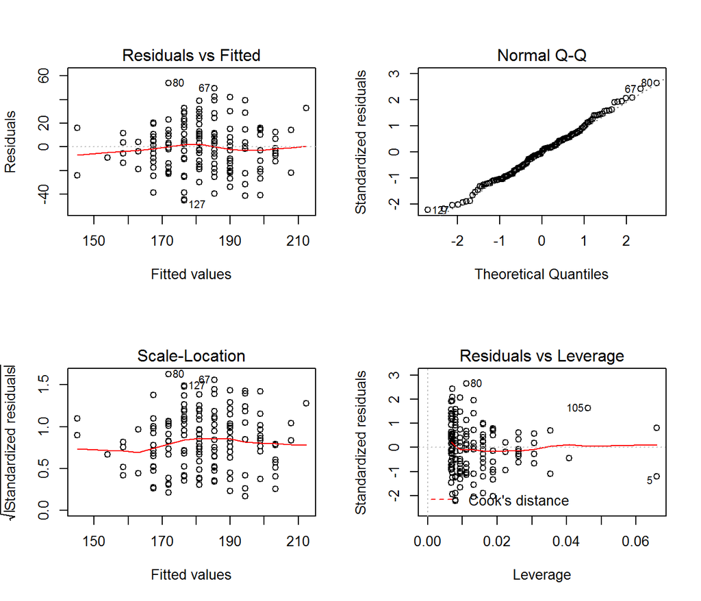

```r
par(mfrow=c(2,2))
plot(dad)
```

The residuals appear to be normally distributed (Normal Q-Q plot), they are centered around zero (Residuals vs Fitted), and there is no evidence of non-constant variance a.k.a. heteroscedasticity (Residuals vs Fitted, and Scale-Location).

There are some potential outliers marked to examine. Records 80, 67 and 127 are marked as potential outliers in 3/4 of the diagnostic plots, but record 105 and 5 have possibly large leverage values.

The guideline for what is considered to be high leverage is 4/N, so for this model it is `4 / NROW(fev)` = 0.03. *Note: I can use the number of rows in the `fev` data set as the N because I have already confirmed that there is no missing data in the variables that are used in the model.*

While we’re examining outliers, let’s calculate the standardized residuals for each case using the `studres()` function available in the `MASS` package. Anything over 3 is considered to be a large value (Afifi top of p 100).

```r
library(MASS)
fev$dad_sresid <- studres(dad)
```

Then view this record.

```r
fev[c(80, 67, 127, 105,5) ,c('fweight', 'fheight', 'dad_sresid')]
```

```
##     fweight fheight dad_sresid
## 80      226      67   2.706493
## 67      235      70   2.467528
## 127     131      68  -2.253975
## 105     245      76   1.638357
## 5       121      61  -1.211665
```

The studentized residuals are not large, the points with high leverage are not flagged as problematic in other plots, and the rest of the assumptions appear to be very well upheld. Thus my conclusion is that no records need to be removed from this analysis.

**4. Repeat 1 -3 for mothers.** Examine the relationship between weight and height for mothers.

```r
cor(fev$mweight, fev$mheight)
```

```
## [1] 0.3175785
```

The correlation coefficient between weight and height for mothers is 0.32, this is a weak correlation.

```r
mom <- lm(mweight ~ mheight, data=fev)
```

```r
ms <- xtable(summary(mom))
print(ms, type='html')
```

|  | Estimate | Std. Error | t value | Pr(>\|t\|) |
| --- | --- | --- | --- | --- |
| (Intercept) | -108.1727 | 62.6674 | -1.73 | 0.0864 |
| mheight | 3.9809 | 0.9770 | 4.07 | 0.0001 |

*Check assumptions* Check linearity:

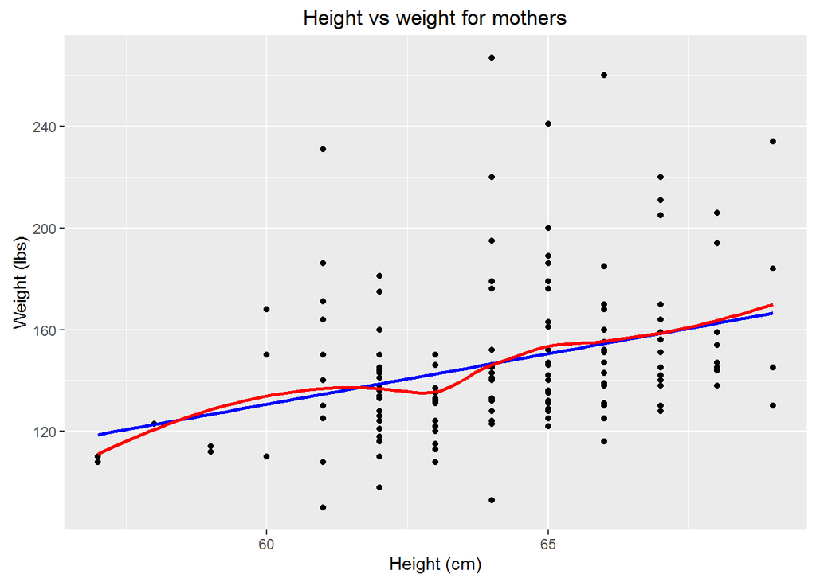

```r
qplot(x=mheight, y=mweight, data=fev, geom="point") +
  geom_smooth(se=FALSE, method = "lm", col="blue") + geom_smooth(se=FALSE, col="red") +
  ggtitle("Height vs weight for mothers") + xlab("Height (cm)") + ylab("Weight (lbs)")
```

There appears to be a linear relationship between weight and height for mothers in the data set. There are some points that appear to have higher than average weight (250+) for their height (63-66cm).

Examine the rest of the diagnostics based on the residuals.

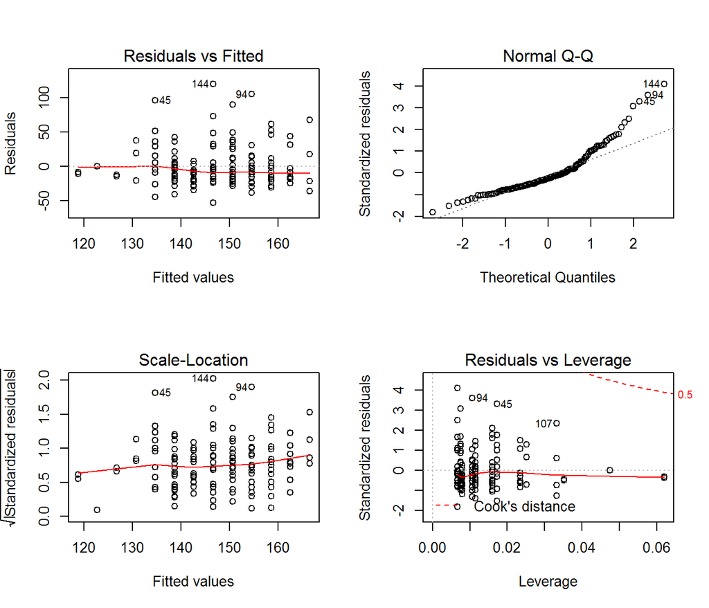

```r
par(mfrow=c(2,2))
plot(mom)
```

The residuals appear to be slightly non-normally distributed, but are centered around zero. There are some records flagged as potential outliers (45, 144, 94, 107) that we should further investigate. The leverage cutoff is the same as for fathers, 0.03.

```r
fev$mom_sresid <- studres(mom)
fev[c(45, 94, 144, 107) ,c('mweight', 'mheight', 'mom_sresid')]
```

```
##     mweight mheight mom_sresid
## 45      231      61   3.416484
## 94      260      66   3.755091
## 144     267      64   4.341981
## 107     234      69   2.366562
```

**5. Discuss why the correlation for fathers appears higher than that for mothers.**

The correlation for fathers appears higher than that for mothers since the data for mothers are more spread out than for fathers. Correlation is a direct function of the variance of both the predictor and outcomes, and so the density of the points around the best fit line dictates the strength of the correlation.

Last updated

```r
Sys.info()
```

```
##                      sysname                      release
##                    "Windows"                      "7 x64"
##                      version                     nodename
## "build 7601, Service Pack 1"                     "C00734"
##                      machine                        login
##                     "x86-64"                 "rdonatello"
##                         user               effective_user
##                 "rdonatello"                 "rdonatello"
```